# UK Used Car

## Recherche d'un modèle

### Analyses

[figure not shown]

### Traitement des fichiers sources

[figure not shown]

### Préparation des données

[figure not shown]

#### Suppression ou Imputation des *anomalies*

[figure not shown]

### Séparation des données

[figure not shown]

### Création du Modèle

[figure not shown]

#### Extract Features

Création de nouvelles variables:

1. `age`: $max(year)-year$
2. `model_count`: nombre d'occurence du modèle dans le dataset
3. `occurence_relative`: $\frac{count(model)}{count(allmodel)}$
4. `mileage_per_year`: $\frac{mileage}{age}$
5. `mpg_per_year`: $\frac{mpg}{age}$
6. `tax_per_year`: $\frac{tax}{age}$
7. `engine_size_per_year`: $\frac{enginesize}{age}$
8. `esoteric_composite_ratio`

Suivant la marque de voiture et/ou le modèle de prédiction créé, certaines améliorent le score de prédictions.

#### Transform Features

1. `PolynomialFeature` pour les variables numériques.
2. `KBinsDiscretizer` pour les variables `mpg`, `tax`, `engine_size`, `year`.
3. `OneHotEncoder` ou `OrdinalEncoder` pour les variables `model`, `brand`, `transmission`, `fuel_type`.

> Pour l'`OrdinalEncoder`, les catégories ont été triées relativement à la variable dépendante `price` par **ordre ascendant**.

#### Échelle discrète

##### MPG

[figure not shown]

##### Tax

[figure not shown]

##### Engine Size

[figure not shown]

### Pipeline

[figure not shown]

### Couches d'optimisation du modèle

[figure not shown]

### Valeurs des paramètres du pipeline

[figure not shown]

## Des modèles

1. Un modèle par marque
2. Un modèle pour toutes les marques
3. Un modèle incrémental pour toutes les marques

### Par marques

Création d'un modèle par marques, One Model By Brand (OMBB).

#### Évaluation du modèle de base (OMBB)

```python
evaluate_all_models(search_term='base-model',exclude=['base_score','all_brand'])
```

```
PERFORMANCE COMPARISON ──────────────────────────────────────────────────────────────────────
```

```
One model by Brand
┏━━━━━━━━━━┳━━━━━━┳━━━━━━━━━┳━━━━━━━━━━━━━━━━━━━━━┳━━━━━━━━━━━━━━━━━━━━━┓
┃  Brand   ┃ RMSE ┃   R2    ┃ Absolute Mean Error ┃     Model path      ┃
┡━━━━━━━━━━╇━━━━━━╇━━━━━━━━━╇━━━━━━━━━━━━━━━━━━━━━╇━━━━━━━━━━━━━━━━━━━━━┩
│   Audi   │ 2866 │ 0.2526  │        1687         │   audi_base-model   │
│   Bmw    │ 2534 │ 0.2053  │        1674         │   bmw_base-model    │
│   Ford   │ 1402 │ -0.1546 │         918         │   ford_base-model   │
│ Hyundai  │ 1585 │ 0.1268  │         891         │ hyundai_base-model  │
│ Mercedes │ 3469 │ 0.1752  │        1803         │ mercedes_base-model │
│   Opel   │ 1146 │ -0.5113 │         785         │   opel_base-model   │
│  Skoda   │ 2743 │ 0.1673  │        1138         │  skoda_base-model   │
│  Toyota  │ 1504 │ 0.2088  │         891         │  toyota_base-model  │
│    Vw    │ 2026 │ 0.1248  │        1191         │    vw_base-model    │
└──────────┴──────┴─────────┴─────────────────────┴─────────────────────┘
```

#### Optimisation du pipeline (OMBB)

```python
evaluate_all_models(search_term='optimize', exclude=['rmse'])
```

```
PERFORMANCE COMPARISON ──────────────────────────────────────────────────────────────────────
```

```
One model by Brand
┏━━━━━━━━━━┳━━━━━━┳━━━━━━━━━━━━━━━━━━━━━┳━━━━━━━━━━━━━━━━━━━┓
┃  Brand   ┃ RMSE ┃ Absolute Mean Error ┃    Model path     ┃
┡━━━━━━━━━━╇━━━━━━╇━━━━━━━━━━━━━━━━━━━━━╇━━━━━━━━━━━━━━━━━━━┩
│   Audi   │ 1847 │        1149         │   audi_optimize   │
│   Bmw    │ 1635 │        1108         │   bmw_optimize    │
│   Ford   │ 801  │         541         │   ford_optimize   │
│ Hyundai  │ 733  │         518         │ hyundai_optimize  │
│ Mercedes │ 2613 │        1211         │ mercedes_optimize │
│   Opel   │ 682  │         463         │   opel_optimize   │
│  Skoda   │ 1486 │         736         │  skoda_optimize   │
│  Toyota  │ 919  │         545         │  toyota_optimize  │
│    Vw    │ 1162 │         761         │    vw_optimize    │
└──────────┴──────┴─────────────────────┴───────────────────┘
```

#### Optimisation de l'estimateur (OMBB)

```python
evaluate_all_models(search_term='estimator',exclude=['all_brand'])
```

```
PERFORMANCE COMPARISON ──────────────────────────────────────────────────────────────────────
```

```
One model by Brand
┏━━━━━━━━━━┳━━━━━━┳━━━━━━━━━━━━━━━━━━━━━┳━━━━━━━━━━━━━━━━━━━━━━━━━━━━━━┓
┃  Brand   ┃ RMSE ┃ Absolute Mean Error ┃          Model path          ┃
┡━━━━━━━━━━╇━━━━━━╇━━━━━━━━━━━━━━━━━━━━━╇━━━━━━━━━━━━━━━━━━━━━━━━━━━━━━┩
│   Audi   │ 1540 │         848         │   audi_perm-estimator_1540   │
│   Bmw    │ 1482 │         959         │   bmw_perm-estimator_1482    │
│   Ford   │ 785  │         507         │   ford_perm-estimator_785    │
│ Hyundai  │ 760  │         536         │  hyundai_perm-estimator_760  │
│ Mercedes │ 2266 │        1237         │ mercedes_perm-estimator_2266 │
│   Opel   │ 707  │         461         │   opel_perm-estimator_707    │
│  Skoda   │ 1435 │         708         │  skoda_perm-estimator_1435   │
│  Toyota  │ 862  │         503         │  toyota_perm-estimator_862   │
│    Vw    │ 963  │         561         │    vw_perm-estimator_963     │
└──────────┴──────┴─────────────────────┴──────────────────────────────┘
```

#### Optimisation du pipeline (OMBB + permutation)

```python
evaluate_all_models(search_term='perm', exclude=[])
```

```
PERFORMANCE COMPARISON ──────────────────────────────────────────────────────────────────────
```

```
One model by Brand
┏━━━━━━━━━━┳━━━━━━┳━━━━━━━━━━━━━━━━━━━━━┳━━━━━━━━━━━━━━━━━━━━┓
┃  Brand   ┃ RMSE ┃ Absolute Mean Error ┃     Model path     ┃
┡━━━━━━━━━━╇━━━━━━╇━━━━━━━━━━━━━━━━━━━━━╇━━━━━━━━━━━━━━━━━━━━┩
│   Audi   │ 1792 │        1096         │   audi_perm_1792   │
│   Bmw    │ 1656 │        1097         │   bmw_perm_1656    │
│   Ford   │ 789  │         554         │   ford_perm_789    │
│ Hyundai  │ 760  │         536         │  hyundai_perm_760  │
│ Mercedes │ 2266 │        1237         │ mercedes_perm_2266 │
│   Opel   │ 707  │         461         │   opel_perm_707    │
│  Skoda   │ 1435 │         708         │  skoda_perm_1435   │
│  Toyota  │ 916  │         580         │  toyota_perm_916   │
│    Vw    │ 1149 │         759         │    vw_perm_1149    │
└──────────┴──────┴─────────────────────┴────────────────────┘
```

#### Optimisation de l'estimateur (OMBB + permutation)

```python
evaluate_all_models(search_term='perm-estimator', exclude=[])
```

```
PERFORMANCE COMPARISON ──────────────────────────────────────────────────────────────────────
```

```
One model by Brand
┏━━━━━━━━━━┳━━━━━━┳━━━━━━━━━━━━━━━━━━━━━┳━━━━━━━━━━━━━━━━━━━━━━━━━━━━━━┓
┃  Brand   ┃ RMSE ┃ Absolute Mean Error ┃          Model path          ┃
┡━━━━━━━━━━╇━━━━━━╇━━━━━━━━━━━━━━━━━━━━━╇━━━━━━━━━━━━━━━━━━━━━━━━━━━━━━┩
│   Audi   │ 1540 │         848         │   audi_perm-estimator_1540   │
│   Bmw    │ 1482 │         959         │   bmw_perm-estimator_1482    │
│   Ford   │ 785  │         507         │   ford_perm-estimator_785    │
│ Hyundai  │ 760  │         536         │  hyundai_perm-estimator_760  │
│ Mercedes │ 2266 │        1237         │ mercedes_perm-estimator_2266 │
│   Opel   │ 707  │         461         │   opel_perm-estimator_707    │
│  Skoda   │ 1435 │         708         │  skoda_perm-estimator_1435   │
│  Toyota  │ 862  │         503         │  toyota_perm-estimator_862   │
│    Vw    │ 963  │         561         │    vw_perm-estimator_963     │
└──────────┴──────┴─────────────────────┴──────────────────────────────┘
```

#### Essais et évaluation de prédictions (OMBB)

```python
evaluate_prediction(model, X_test, y_test,sample=10,add_columns=['model','transmission','fuel_type'])
```

```
RMSE: 1030.727027367902
```

```
MODEL PREDICTION TESTING ────────────────────────────────────────────────────────────────────
```

```
Prediction results
┏━━━━━━━━━━━━┳━━━━━━━━━━━━┳━━━━━━━┳━━━━━━━━━━━━┳━━━━━━━━━┳━━━━━━━━━━━━━━┳━━━━━━━━━━━┓
┃ Prediction ┃ Real Price ┃ Error ┃ Percentage ┃  model  ┃ transmission ┃ fuel_type ┃
┡━━━━━━━━━━━━╇━━━━━━━━━━━━╇━━━━━━━╇━━━━━━━━━━━━╇━━━━━━━━━╇━━━━━━━━━━━━━━╇━━━━━━━━━━━┩
│   10451    │   10000    │ -451  │    -5 %    │  Astra  │  Semi-Auto   │  Petrol   │
│   13763    │   13481    │ -282  │    -2 %    │  Astra  │    Manual    │  Petrol   │
│    8691    │    8298    │ -393  │    -5 %    │  Mokka  │    Manual    │  Petrol   │
│   10279    │    8290    │ -1989 │   -24 %    │  Astra  │    Manual    │  Petrol   │
│    7968    │    7994    │  26   │    0 %     │  Corsa  │    Manual    │  Petrol   │
│   13959    │   12049    │ -1910 │   -16 %    │ Mokka X │  Semi-Auto   │  Petrol   │
│   10761    │    9959    │ -802  │    -8 %    │  Astra  │  Automatic   │  Diesel   │
│    8664    │    9135    │  471  │    5 %     │  Corsa  │    Manual    │  Petrol   │
│   12697    │   12999    │  302  │    2 %     │  Mokka  │    Manual    │  Petrol   │
│   11474    │   10195    │ -1279 │   -13 %    │ Mokka X │    Manual    │  Petrol   │
└────────────┴────────────┴───────┴────────────┴─────────┴──────────────┴───────────┘
```

#### Courbe d'apprentissage

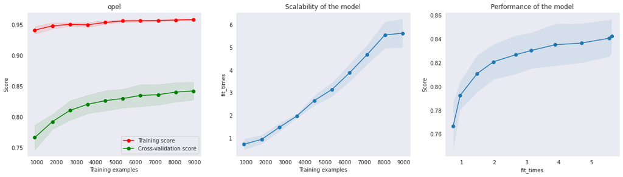

```python
plot_learning_curve(model, 'opel', X_train, y_train, axes=None, ylim=None, cv=10,
                        n_jobs=2, train_sizes=np.linspace(.1, 1.0, 10), show=True,savefig=False)
```

### Toutes marques

1. fusion des données en une seule source de données

```python
bmmd.evaluate_model(model_filename='all_brands_estimator_optimized_rmse_1912.joblib',data_filename='all_brands.csv',verbose=False)
```

```
Loading all_brands_estimator_optimized_rmse_1912.joblib
```

```
PERFORMANCE COMPARISON ──────────────────────────────────────────────────────────────────────
```

```
One model by Brand
┏━━━━━━━━━━━━━━━━━━━━━━┳━━━━━━┳━━━━━━━━━━━━━━━━━━━━━┳━━━━━━━━━━━━━━━━━━━━━━━━━┓
┃        Brand         ┃ RMSE ┃ Absolute Mean Error ┃       Model path        ┃
┡━━━━━━━━━━━━━━━━━━━━━━╇━━━━━━╇━━━━━━━━━━━━━━━━━━━━━╇━━━━━━━━━━━━━━━━━━━━━━━━━┩
│ Merged Brand Dataset │ 1912 │         826         │ all_brands_estimator... │
└──────────────────────┴──────┴─────────────────────┴─────────────────────────┘
```

```python
evaluate_prediction(model, X_test, y_test,sample=10,add_columns=['brand','model','transmission','fuel_type'])
```

```
Loading all_brands.joblib
RMSE: 3398.386598062283
```

```
MODEL PREDICTION TESTING ────────────────────────────────────────────────────────────────────
```

```
Prediction results
┏━━━━━━━━━━━━┳━━━━━━━━━━━━┳━━━━━━━┳━━━━━━━━━━━━┳━━━━━━━━┳━━━━━━━━━┳━━━━━━━━━━━━━━┳━━━━━━━━━━┓
┃ Prediction ┃ Real Price ┃ Error ┃ Percentage ┃ brand  ┃  model  ┃ transmission ┃ fuel_ty… ┃
┡━━━━━━━━━━━━╇━━━━━━━━━━━━╇━━━━━━━╇━━━━━━━━━━━━╇━━━━━━━━╇━━━━━━━━━╇━━━━━━━━━━━━━━╇━━━━━━━━━━┩
│   17969    │   17991    │  22   │    0 %     │ toyota │  C-HR   │  Automatic   │  Petrol  │
│   13883    │   11995    │ -1888 │   -16 %    │ toyota │  Yaris  │  Automatic   │  Hybrid  │
│   26001    │   25190    │ -811  │    -3 %    │ skoda  │  Karoq  │  Automatic   │  Diesel  │
│   10959    │   14398    │ 3439  │    24 %    │  opel  │ Mokka X │  Semi-Auto   │  Petrol  │
│   33102    │   26825    │ -6277 │   -23 %    │  bmw   │ 3 Seri… │  Automatic   │  Petrol  │
│   11265    │   18490    │ 7225  │    39 %    │  audi  │   Q2    │  Semi-Auto   │  Petrol  │
│   10313    │   10494    │  181  │    2 %     │ toyota │  Yaris  │    Manual    │  Petrol  │
│   10979    │    9898    │ -1081 │   -11 %    │   vw   │ Golf SV │    Manual    │  Diesel  │
│   34515    │   36984    │ 2469  │    7 %     │  audi  │   Q5    │  Automatic   │  Diesel  │
│   28188    │   28919    │  731  │    3 %     │  bmw   │ 5 Seri… │  Semi-Auto   │  Diesel  │
└────────────┴────────────┴───────┴────────────┴────────┴─────────┴──────────────┴──────────┘
```

### Entraînement Incrémental

Le model est entrainé sur chaque jeu de données en conservant les arbres précédemment créés.

```python
iterative_model = get_one_model_for_all_iterative(model_to_dump=True, evaluation=True, verbose=False)
```

```
PERFORMANCE COMPARISON ──────────────────────────────────────────────────────────────────────
```

```
One model by Brand
┏━━━━━━━━━━━━┳━━━━━━┳━━━━━━━━┳━━━━━━━━━━━━━━━━━━━━━┳━━━━━━━━━━━━━━━━━━━━━━━━┓
┃   Brand    ┃ RMSE ┃   R2   ┃ Absolute Mean Error ┃       Model path       ┃
┡━━━━━━━━━━━━╇━━━━━━╇━━━━━━━━╇━━━━━━━━━━━━━━━━━━━━━╇━━━━━━━━━━━━━━━━━━━━━━━━┩
│ Inc. Model │ 7229 │ 0.5726 │        4363         │ all_brand_model_7229.0 │
└────────────┴──────┴────────┴─────────────────────┴────────────────────────┘
```

```python
bmmd.evaluate_model(model_filename='all_brand_model_7229_estimator_optimized_rmse_1771.joblib', data_filename='all_brands.csv',verbose=False)
```

```
Loading all_brand_model_7229_estimator_optimized_rmse_1771.joblib
```

```
PERFORMANCE COMPARISON ──────────────────────────────────────────────────────────────────────
```

```
One model by Brand
┏━━━━━━━━━━━━━━━━━━━━━━┳━━━━━━┳━━━━━━━━━━━━━━━━━━━━━┳━━━━━━━━━━━━━━━━━━━━━━━━━┓
┃        Brand         ┃ RMSE ┃ Absolute Mean Error ┃       Model path        ┃
┡━━━━━━━━━━━━━━━━━━━━━━╇━━━━━━╇━━━━━━━━━━━━━━━━━━━━━╇━━━━━━━━━━━━━━━━━━━━━━━━━┩
│ Merged Brand Dataset │ 1771 │         758         │ all_brand_model_7229... │
└──────────────────────┴──────┴─────────────────────┴─────────────────────────┘
```

```python
evaluate_prediction(iterative_model, X_test, y_test,sample=10,add_columns=['brand','model','transmission','fuel_type'])
```

```
RMSE: 2888.984618587985
```

```
MODEL PREDICTION TESTING ────────────────────────────────────────────────────────────────────
```

```
Prediction results
┏━━━━━━━━━━━━┳━━━━━━━━━━━━┳━━━━━━━┳━━━━━━━━━━━━┳━━━━━━━━┳━━━━━━━━━┳━━━━━━━━━━━━━━┳━━━━━━━━━━┓
┃ Prediction ┃ Real Price ┃ Error ┃ Percentage ┃ brand  ┃  model  ┃ transmission ┃ fuel_ty… ┃
┡━━━━━━━━━━━━╇━━━━━━━━━━━━╇━━━━━━━╇━━━━━━━━━━━━╇━━━━━━━━╇━━━━━━━━━╇━━━━━━━━━━━━━━╇━━━━━━━━━━┩
│   21023    │   17991    │ -3032 │   -17 %    │ toyota │  C-HR   │  Automatic   │  Petrol  │
│   13564    │   11995    │ -1569 │   -13 %    │ toyota │  Yaris  │  Automatic   │  Hybrid  │
│   26475    │   25190    │ -1285 │    -5 %    │ skoda  │  Karoq  │  Automatic   │  Diesel  │
│   12609    │   14398    │ 1789  │    12 %    │  opel  │ Mokka X │  Semi-Auto   │  Petrol  │
│   34077    │   26825    │ -7252 │   -27 %    │  bmw   │ 3 Seri… │  Automatic   │  Petrol  │
│   17409    │   18490    │ 1081  │    6 %     │  audi  │   Q2    │  Semi-Auto   │  Petrol  │
│   10343    │   10494    │  151  │    1 %     │ toyota │  Yaris  │    Manual    │  Petrol  │
│   11275    │    9898    │ -1377 │   -14 %    │   vw   │ Golf SV │    Manual    │  Diesel  │
│   35837    │   36984    │ 1147  │    3 %     │  audi  │   Q5    │  Automatic   │  Diesel  │
│   25763    │   28919    │ 3156  │    11 %    │  bmw   │ 5 Seri… │  Semi-Auto   │  Diesel  │
└────────────┴────────────┴───────┴────────────┴────────┴─────────┴──────────────┴──────────┘
```

## Sources

### Notebooks

#### Files Explorations

- [Files Comparison](https://github.com/bortch/secondhandcar/blob/main/all_data_files_exploration.ipynb)
- [Files Creation (test)](https://github.com/bortch/secondhandcar/blob/main/generate_all_brands_csv.ipynb)

#### EDA

- [EDA Audi](https://github.com/bortch/secondhandcar/blob/main/EDA_audi.ipynb)
- [EDA All Brands train_set unprocessed](https://github.com/bortch/secondhandcar/blob/main/EDA_all_brands_train_set_unprocessed.ipynb)
- [EDA All Brands train_set processed](https://github.com/bortch/secondhandcar/blob/main/Analyse_train_set_processed.ipynb)

#### Preprocessing

- [Research on light preprocessing All Brands (notebook test)](https://github.com/bortch/secondhandcar/blob/main/light_preprocessing_all_data_train_set.ipynb)
- [Research Preprocessing All Brands (notebook test)](https://github.com/bortch/secondhandcar/blob/main/preprocessing_all_data_train_set.ipynb)

### Scripts

#### Steps Scripts

1. [preprocessing](https://github.com/bortch/secondhandcar/blob/main/file_processing.py)
2. [prepare data](https://github.com/bortch/secondhandcar/blob/main/prepare_data.py)
3. [split data (unused)](https://github.com/bortch/secondhandcar/blob/main/split_data.py)
4. Build Model:
   - [build One Model by Brand](https://github.com/bortch/secondhandcar/blob/main/build_model_by_brand.py)
   - [build One Model for All Brands](https://github.com/bortch/secondhandcar/blob/main/build_model_for_merged_data.py)
   - [build model One for All Brands (incremental)](https://github.com/bortch/secondhandcar/blob/main/build_model.py)

### Libraries

#### Local

- [build model](https://github.com/bortch/secondhandcar/blob/main/build_model.py)
- [Optimize Model](https://github.com/bortch/secondhandcar/blob/main/optimize_model.py)

#### Extern

- bs_lib